# PSGY4009

Q+A about assessment, the GLM in more detail

Denis Schluppeck

2025-11-04

## Attendance

[figure not shown]

qr code

## Today

**Assessment**

- A bit more detail on the written assessment
- General advice on writing, structure

**The General Linear Model (GLM)**

- intuition / non-mathematical explanation
- (how to get hold of my *interactive* notebooks)
- some of the nitty-gritty (in `Matlab`)
- demo analysis in `fsl` (quick walk-through)

**Kinds of designs**

- task, resting state, connectivity, …

## Learning objectives

By the end of the lecture you should:

- know what’s expected in coursework
- have all the information to get started on assessment
- understand the GLM in principle
- appreciate some of the technical details of GLM analysis
- have some knowledge of different kinds of “designs” / approaches to fMRI for neuroscience

## Assessment

- Written assignment (max 3000 words) including a 250 word abstract.
- Details on [moodle (2025/26)](https://moodle.nottingham.ac.uk/course/section.php?id=1982033).

> The written assignment for this module is an essay about how functional magnetic resonance imaging and/or brain stimulation can be used to study different neuroscience questions. It should cover two topics and/or methods from the course.

## Not just a literature review

> One aim of the assignment is to make you think about the methodological choices the experimenters have to make. After a brief summary of the state of the literature in your area, there should be therefore be a component that talks about how you might extend some previous findings.

## On moodle

[figure not shown]

word doc template

## Guided submission

There are very specific suggestions for how you can tackle each section in turn

**overall word limit, 3000w - stick to this limit**)

- Title of project (suggested ~10 words)
- Lay Summary (max 250 words, one paragraph)
- Scientific Summary (max 250 words, one paragraph)
- Background of the project (suggested 600 words)
- Questions to be answered (suggested 200 words)
- Plan of investigation (suggested 500 words)
- Details of data analysis (suggested 500 words)
- Expected outcomes (suggested 200 words & 1-2 figures)
- Theoretical & practical implications (suggested 500 words)
- References

## Things that you might wonder about:

- Plan of investigation (suggested 500 words)
- Details of data analysis (suggested 500 words)
- Expected outcomes (suggested 200 words & 1-2 figures)

> But I don’t have any data (yet?). How to square that circle??

## What do we look for?

**Content**

The **content** of your coursework is (obviously) important - topic choice - methodological details included - facts correct?

**… but writing!**

- clear, concise, economic
- line of argument?
- structure easy to follow
- …

## Strunk & White - *Elements of Style*

If you haven’t read this little book (26 pages), take the time!

[free online PDF of the book](https://faculty.washington.edu/heagerty/Courses/b572/public/StrunkWhite.pdf)

## The GLM - a quick walk-through

### Some notes for my demo

```bash
cd ~/projects/hands-on-brain-data
julia # which starts julia

julia> using Pluto
julia> Pluto.run()

# "what_is_linearReg.jl"
```

[Link to Install instructions](https://echo360.org.uk/public/media/cb45dbfd-de4a-4180-9700-bc8c48ddf6f3)

## in `Matlab`

### Some notes for my demo

```matlab
cd ~/projects/hands-on-brain-data
cd data
X = load('design-3.txt')
y = load('timecourse.txt')
X\y
% regress(), pinv()
```

## in `fsl`

```bash
cd ~/projects/hands-on-brain-data-demo
cd data
fsleyes filtered_func_data
fsl &
# simple block design ... stats: 6, (12, 12, 12)
```

## in `fsl`/`fsleyes`

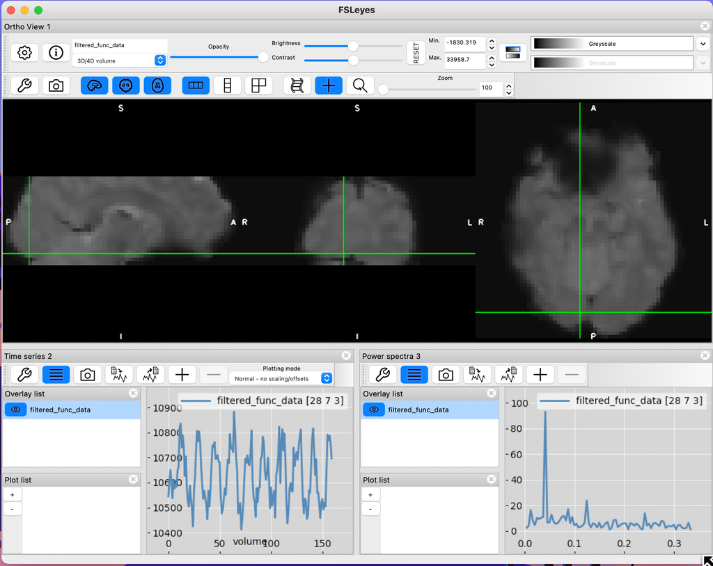

## Kinds of designs / approaches

Two directions, in which people elaborate experiments:

1. **tasks, stimuli** have become more sophisticated
2. **data analysis methods** are changing all the time

## Tasks

You can find lots of versions of these across all domains of cognitive neuroscience…

- task-based experiments
  - block designs, event-related designs, mixed, …
  - “continuous” (eg watching movies)
- resting state fMRI (rsFMRI)

## Example

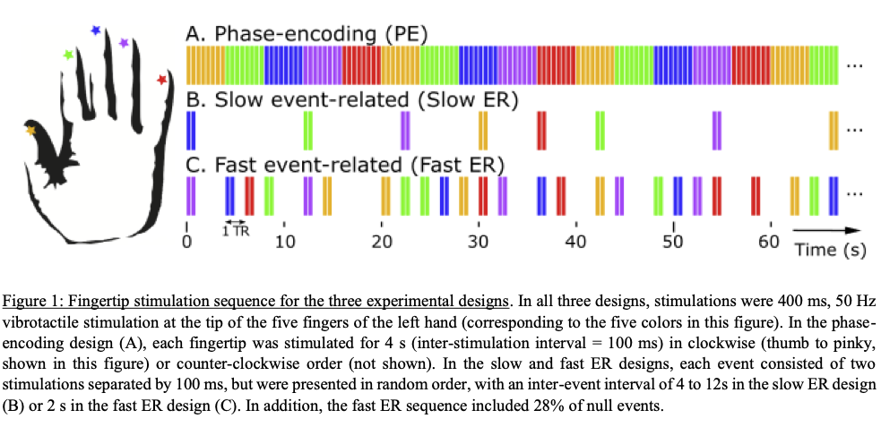

## Analysis methods

- GLM, linear regression (the “workhorse” of fMRI analysis)
- data-driven methods (search for patterns in the data)
  - *independent component analysis*, ICA (dimensionality reduction techniques)
  - seed-based correlation methods
  - network analysis, …
- machine learning, *decoding*

## GLM

We have just seen a bit more of this in action

## Resting state fMRI

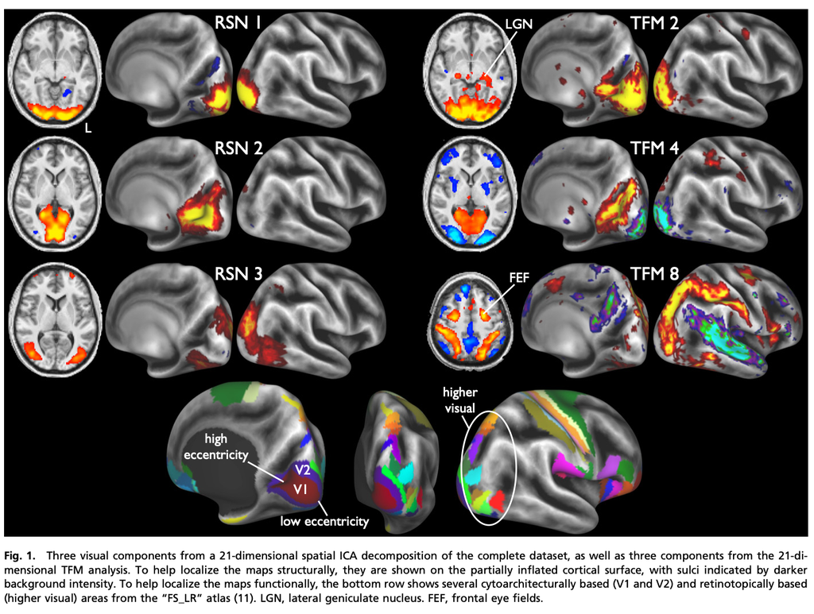

example rs analysis

[Smith et al, 2012, PNAS](https://www.pnas.org/doi/epdf/10.1073/pnas.1121329109)

## Decoding, multivariate analysis

Variously: *classification*, SVM (support vector machines), decoding, even “mind reading”, …

**Aim:** try to use **data** - the pattern of activity across many voxels (and trials) - to figure out which stimulus was being displayed.

## First use, classic reference

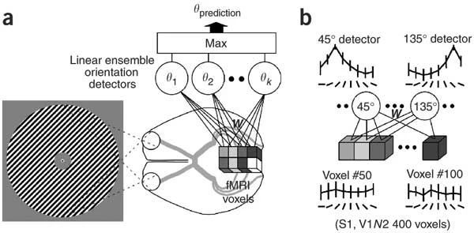

Kamitani and Tong, 2005

[Kamitani & Tong, 2005](https://www.ncbi.nlm.nih.gov/pmc/articles/PMC1808230/)

## Thanks

Hope you found this helpful.

See you soon!

## Colophon

- This presentation was made with `quarto` and `revealjs`.
- Uses a font called `Atkinson Hyerlegible`, which was designed to work better for people with low vision: available via [google fonts](https://fonts.google.com/specimen/Atkinson+Hyperlegible).